# Projet de scoring avec R

Yasmine Ben Taarit || Elève-ingénieure en 3ème année à l’ESSAI

5 décembre 2017

Ce document est un guide pour réaliser un score avec R à travers un cas pratique. Il ne revient pas sur les aspects mathématiques de la construction d’un score, mais insite plutôt sur les commandes en R et sur l’exploitation des résultats. Il se subdivise en quatre parties:

1 - Description de l’objectif de l’étude et des données

2 - Préparation des données et premières analyses

3 - Construction et validation du score

4 - Interprétation des résultats

# Objectif de l’étude et description des données

## Introduction

Le scoring est une technique de hiérarchisation des données qui permet d’évaluer par une note ou un score la probabilité qu’un individu réponde à une sollicitation ou appartienne à la cible recherchée.

Le score est en général obtenu à partir des données quantitatives et qualitatives disponibles sur l’individu (données socio-demo, comportement d’achat, réponses précédentes, …) auxquelles sont appliquées un modèle de scoring.

Dans ce travail, on va avoir recours à trois principales techniques en data mining à savoir:

- Régression logistique
- Arbres de décision
- Forêts aléatoires

## Etude cas

On s’intéresse pour notre étude de cas à une base de données qui contient des données 726 clients pour lesquels on souhaite prédire leurs crédibilités.

### Importation de la base de données

|  | kredit | laufkont | laufzeit | moral | verw | hoehe | sparkont | beszeit | rate | famges | buerge | wohnzeit | verm | alter | weitkred | wohn | bishkred | beruf | pers | telef | gastarb |
| --- | --- | --- | --- | --- | --- | --- | --- | --- | --- | --- | --- | --- | --- | --- | --- | --- | --- | --- | --- | --- | --- |
| 1 | 1 | 2 | 12 | 2 | 9 | 841 | 2 | 4 | 2 | 2 | 1 | 4 | 1 | 23 | 3 | 1 | 1 | 2 | 1 | 1 | 1 |
| 2 | 1 | 4 | 18 | 4 | 3 | 1098 | 1 | 1 | 4 | 2 | 1 | 4 | 3 | 65 | 3 | 2 | 2 | 1 | 1 | 1 | 1 |
| 3 | 1 | 2 | 24 | 2 | 3 | 3758 | 3 | 1 | 1 | 2 | 1 | 4 | 4 | 23 | 3 | 1 | 1 | 1 | 1 | 1 | 1 |
| 4 | 1 | 2 | 48 | 3 | 10 | 7582 | 2 | 1 | 2 | 3 | 1 | 4 | 4 | 31 | 3 | 2 | 1 | 4 | 1 | 2 | 1 |
| 5 | 1 | 2 | 18 | 2 | 3 | 3213 | 3 | 2 | 1 | 4 | 1 | 3 | 1 | 25 | 3 | 1 | 1 | 3 | 1 | 1 | 1 |
| 6 | 1 | 2 | 36 | 4 | 3 | 2337 | 1 | 5 | 4 | 3 | 1 | 4 | 1 | 36 | 3 | 2 | 1 | 3 | 1 | 1 | 1 |
| 7 | 1 | 4 | 11 | 4 | 0 | 7228 | 1 | 3 | 1 | 3 | 1 | 4 | 2 | 39 | 3 | 2 | 2 | 2 | 1 | 1 | 1 |
| 8 | 1 | 2 | 12 | 4 | 0 | 3124 | 1 | 2 | 1 | 3 | 1 | 3 | 1 | 49 | 1 | 2 | 2 | 2 | 2 | 1 | 1 |
| 9 | 0 | 2 | 36 | 2 | 5 | 2384 | 1 | 2 | 4 | 3 | 1 | 1 | 4 | 33 | 3 | 1 | 1 | 2 | 1 | 1 | 1 |
| 10 | 1 | 2 | 12 | 4 | 4 | 1424 | 1 | 4 | 4 | 3 | 1 | 3 | 2 | 26 | 3 | 2 | 1 | 3 | 1 | 1 | 1 |

[output cut: 716 more lines]

### Description du jeu de données

- Alter: Age
- Beruf: Profession
- Beszeit: Stabilité dans l’emploi
- Buerge: Autres garants pour le remboursement du crédit
- Bishkred: Nombre de précédents crédit à la banque
- Famges: Statut marital/Sexe
- Gastarb: Travailleur étranger
- Kredit: Solvabilité du client
- Laufkont: Etat de compte
- Laufzeit: Durée de crédit (mois)
- Moral: Comportement passé pour remboursser d’autres crédits
- Pers: Nombre de personnes gérant le crédit
- Rate: Pas de mensualités dans le revenu disponible en %
- Telef: Possession d’une ligne téléphonique
- Sparkont: Valeur des ressources financières du client
- Verm: Actif en dur
- Verw: Objectif du crédit
- Weitkred: Autres crédits en cours
- Wohn: Type de logement
- Wohnzeit: Temps passé

### Définition de l’objectif de la modélisation

On souhaite déterminer la probabilité d’avoir un client solvable compte tenu des descripteurs relevés sur les 726 clients kredit = f(beruf, age, bishkred, wohn, etc… ).

### La démarche de modélisation

Comme toute bonne démarche de modélisation, la construction d’un bon score se fait par une succession d’étapes plus ou moins fondamentales en fonction des praticiens. Néanmoins tous s’accordent plus ou moins à respecter les suivantes:

- Analyse exploratoire : Que contient le jeu de données? Y a t-il beaucoup de valeurs manquantes?
- Vérifier la liaison entre les descripteurs et la variable à expliquer
- Identifier les prédicteurs importants et les redondants afin de faire un modèle parcimonieux (très important lorsqu’on souhaite faire de la prévision)
- Appliquer trois techniques de modélisation à savoir **la régression logistique**, **l’arbre de décision** et **Forêts aléatoires**.
- Comparer les modèles obtenus et retenir le modèle le plus adéquat selon l’objectif de l’étude

Nous suivrons ces étapes et résoudrons le problème posé par notre étude de cas.

## Modélisation

### Chargement des données

```r
names(data)
```

```
##  [1] "kredit"   "laufkont" "laufzeit" "moral"    "verw"     "hoehe"
##  [7] "sparkont" "beszeit"  "rate"     "famges"   "buerge"   "wohnzeit"
## [13] "verm"     "alter"    "weitkred" "wohn"     "bishkred" "beruf"
## [19] "pers"     "telef"    "gastarb"
```

### Analyse exploratoire

```r
str(data)
```

```
## 'data.frame':    726 obs. of  21 variables:
##  $ kredit  : int  1 1 1 1 1 1 1 1 0 1 ...
##  $ laufkont: int  2 4 2 2 2 2 4 2 2 2 ...
##  $ laufzeit: int  12 18 24 48 18 36 11 12 36 12 ...
##  $ moral   : int  2 4 2 3 2 4 4 4 2 4 ...
##  $ verw    : int  9 3 3 10 3 3 0 0 5 4 ...
##  $ hoehe   : int  841 1098 3758 7582 3213 2337 7228 3124 2384 1424 ...
##  $ sparkont: int  2 1 3 2 3 1 1 1 1 1 ...
##  $ beszeit : int  4 1 1 1 2 5 3 2 2 4 ...
##  $ rate    : int  2 4 1 2 1 4 1 1 4 4 ...
##  $ famges  : int  2 2 2 3 4 3 3 3 3 3 ...
##  $ buerge  : int  1 1 1 1 1 1 1 1 1 1 ...
##  $ wohnzeit: int  4 4 4 4 3 4 4 3 1 3 ...
##  $ verm    : int  1 3 4 4 1 1 2 1 4 2 ...
##  $ alter   : int  23 65 23 31 25 36 39 49 33 26 ...
##  $ weitkred: int  3 3 3 3 3 3 3 1 3 3 ...
##  $ wohn    : int  1 2 1 2 1 2 2 2 1 2 ...
##  $ bishkred: int  1 2 1 1 1 1 2 2 1 1 ...
##  $ beruf   : int  2 1 1 4 3 3 2 2 2 3 ...
##  $ pers    : int  1 1 1 1 1 1 1 2 1 1 ...
##  $ telef   : int  1 1 1 2 1 1 1 1 1 1 ...
##  $ gastarb : int  1 1 1 1 1 1 1 1 1 1 ...
```

```r
summary(data)
```

```
##      kredit          laufkont        laufzeit         moral
##  Min.   :0.0000   Min.   :2.000   Min.   : 4.00   Min.   :0.000
##  1st Qu.:1.0000   1st Qu.:2.000   1st Qu.:12.00   1st Qu.:2.000
##  Median :1.0000   Median :4.000   Median :18.00   Median :2.000
##  Mean   :0.7727   Mean   :3.172   Mean   :20.74   Mean   :2.616
##  3rd Qu.:1.0000   3rd Qu.:4.000   3rd Qu.:24.00   3rd Qu.:4.000
##  Max.   :1.0000   Max.   :4.000   Max.   :72.00   Max.   :4.000
##       verw            hoehe          sparkont        beszeit
##  Min.   : 0.000   Min.   :  250   Min.   :1.000   Min.   :1.000
##  1st Qu.: 1.000   1st Qu.: 1386   1st Qu.:1.000   1st Qu.:3.000
##  Median : 3.000   Median : 2300   Median :1.000   Median :3.000
##  Mean   : 3.006   Mean   : 3308   Mean   :2.299   Mean   :3.409
##  3rd Qu.: 3.000   3rd Qu.: 4028   3rd Qu.:4.000   3rd Qu.:5.000
##  Max.   :10.000   Max.   :18424   Max.   :5.000   Max.   :5.000
##       rate           famges          buerge         wohnzeit
##  Min.   :1.000   Min.   :1.000   Min.   :1.000   Min.   :1.000
##  1st Qu.:2.000   1st Qu.:2.000   1st Qu.:1.000   1st Qu.:2.000
##  Median :3.000   Median :3.000   Median :1.000   Median :3.000
##  Mean   :2.941   Mean   :2.701   Mean   :1.124   Mean   :2.785
##  3rd Qu.:4.000   3rd Qu.:3.000   3rd Qu.:1.000   3rd Qu.:4.000
##  Max.   :4.000   Max.   :4.000   Max.   :3.000   Max.   :4.000
##       verm          alter          weitkred          wohn
##  Min.   :1.00   Min.   :19.00   Min.   :1.000   Min.   :1.000
##  1st Qu.:1.00   1st Qu.:27.00   1st Qu.:3.000   1st Qu.:2.000
##  Median :2.00   Median :33.00   Median :3.000   Median :2.000
##  Mean   :2.35   Mean   :35.62   Mean   :2.685   Mean   :1.937
##  3rd Qu.:3.00   3rd Qu.:41.00   3rd Qu.:3.000   3rd Qu.:2.000
##  Max.   :4.00   Max.   :74.00   Max.   :3.000   Max.   :3.000
##     bishkred         beruf            pers           telef
##  Min.   :1.000   Min.   :1.000   Min.   :1.000   Min.   :1.000
##  1st Qu.:1.000   1st Qu.:3.000   1st Qu.:1.000   1st Qu.:1.000
##  Median :1.000   Median :3.000   Median :1.000   Median :1.000
##  Mean   :1.417   Mean   :2.915   Mean   :1.142   Mean   :1.424
##  3rd Qu.:2.000   3rd Qu.:3.000   3rd Qu.:1.000   3rd Qu.:2.000
##  Max.   :4.000   Max.   :4.000   Max.   :2.000   Max.   :2.000
##     gastarb
##  Min.   :1.00
##  1st Qu.:1.00
##  Median :1.00
##  Mean   :1.03
##  3rd Qu.:1.00
##  Max.   :2.00
```

On remarque que la variabe cible kredit a été traitée comme une variable numérique: On rémédie à cela en la transformant en type facteur. De même pour les autres variables.

```r
data$kredit<-factor(data$kredit)
data.factor<-data
data.factor$beruf<-factor(data$beruf)
data.factor$beszeit<-factor(data$beszeit)
data.factor$buerge<-factor(data$buerge)
data.factor$bishkred<-factor(data$bishkred)
data.factor$famges<-factor(data$famges)
data.factor$gastarb<-factor(data$gastarb)
data.factor$laufkont<-factor(data$laufkont)
data.factor$moral<-factor(data$moral)
data.factor$pers<-factor(data$pers)
data.factor$rate<-factor(data$rate)
data.factor$telef<-factor(data$telef)
data.factor$sparkont<-factor(data$sparkont)
data.factor$verm<-factor(data$verm)
data.factor$verw<-factor(data$verw)
data.factor$weitkred<-factor(data$weitkred)
data.factor$wohn<-factor(data$wohn)
data.factor$wohnzeit<-factor(data$wohnzeit)
summary(data.factor)
```

```
##  kredit  laufkont    laufzeit     moral        verw         hoehe
##  0:165   2:269    Min.   : 4.00   0: 27   3      :226   Min.   :  250
##  1:561   3: 63    1st Qu.:12.00   1: 27   0      :156   1st Qu.: 1386
##          4:394    Median :18.00   2:370   2      :109   Median : 2300
##                   Mean   :20.74   3: 76   9      : 82   Mean   : 3308
##                   3rd Qu.:24.00   4:226   1      : 77   3rd Qu.: 4028
##                   Max.   :72.00           6      : 37   Max.   :18424
##                                           (Other): 39
##  sparkont beszeit rate    famges  buerge  wohnzeit verm        alter
##  1:384    1: 41   1:100   1: 33   1:669   1: 95    1:212   Min.   :19.00
##  2: 91    2:123   2:177   2:222   2: 24   2:247    2:152   1st Qu.:27.00
##  3: 55    3:247   3:115   3:400   3: 33   3:103    3:258   Median :33.00
##  4: 42    4:128   4:334   4: 71           4:281    4:104   Mean   :35.62
##  5:154    5:187                                            3rd Qu.:41.00
##                                                            Max.   :74.00
##
##  weitkred wohn    bishkred beruf   pers    telef   gastarb
##  1: 97    1:114   1:451    1: 16   1:623   1:418   1:704
##  2: 35    2:544   2:251    2:141   2:103   2:308   2: 22
##  3:594    3: 68   3: 20    3:458
##                   4:  4    4:111
##
##
##
```

Nous allons supprimer toutes les valeurs manquantes possibles du jeu de données

```r
data<-na.omit(data)
```

Examinons les distributions

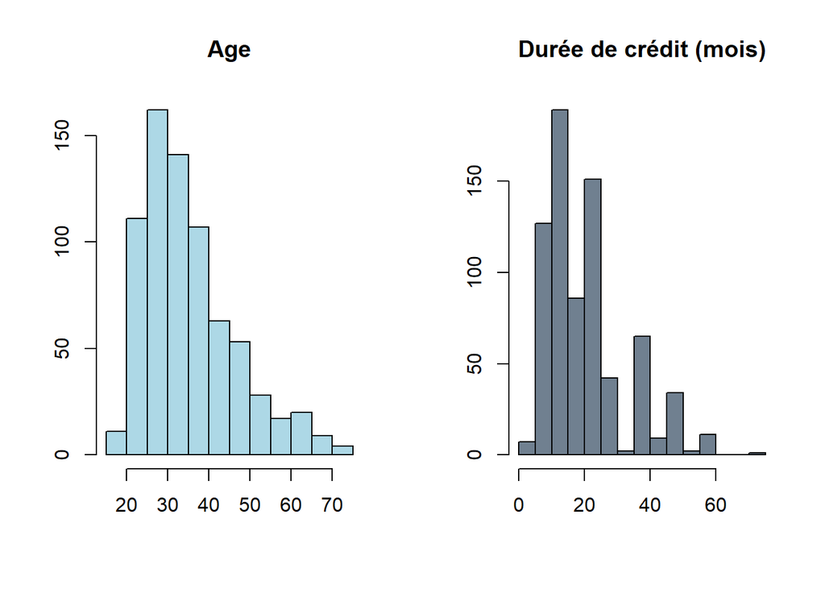

```r
attach(data)
par(mfrow=c(1,2))
hist(x = alter, col = "lightblue", main = "Age", xlab = "", ylab = "")
hist(x = laufzeit, col = "slategray", main = "Durée de crédit (mois)", xlab = "", ylab = "")
```

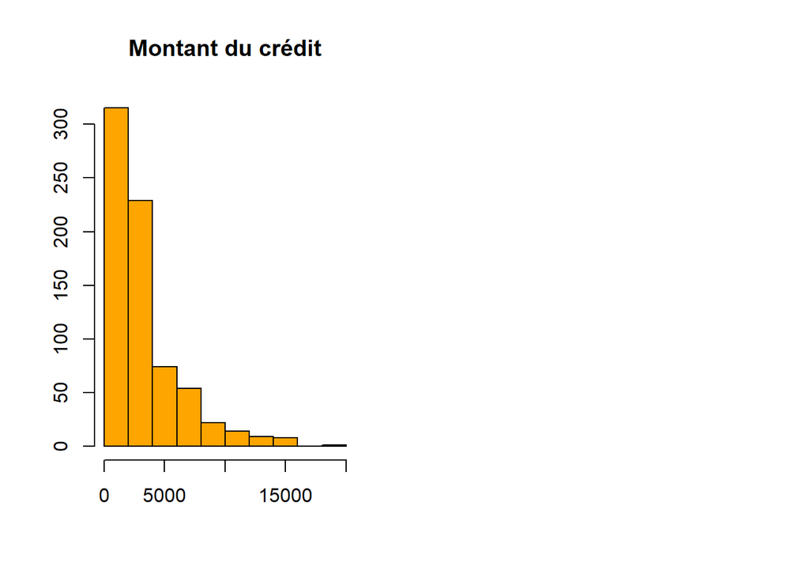

```r
hist(x =hoehe, col = "orange", main = "Montant du crédit", xlab = "", ylab = "")
```

### Valeurs aberrantes

Les valeurs aberrantes dépendent de la distribution et surtout de l’objet de l’étude. Regardons encore une fois les statistiques de base.

```r
summary(data)
```

```
##  kredit     laufkont        laufzeit         moral            verw
##  0:165   Min.   :2.000   Min.   : 4.00   Min.   :0.000   Min.   : 0.000
##  1:561   1st Qu.:2.000   1st Qu.:12.00   1st Qu.:2.000   1st Qu.: 1.000
##          Median :4.000   Median :18.00   Median :2.000   Median : 3.000
##          Mean   :3.172   Mean   :20.74   Mean   :2.616   Mean   : 3.006
##          3rd Qu.:4.000   3rd Qu.:24.00   3rd Qu.:4.000   3rd Qu.: 3.000
##          Max.   :4.000   Max.   :72.00   Max.   :4.000   Max.   :10.000
##      hoehe          sparkont        beszeit           rate
##  Min.   :  250   Min.   :1.000   Min.   :1.000   Min.   :1.000
##  1st Qu.: 1386   1st Qu.:1.000   1st Qu.:3.000   1st Qu.:2.000
##  Median : 2300   Median :1.000   Median :3.000   Median :3.000
##  Mean   : 3308   Mean   :2.299   Mean   :3.409   Mean   :2.941
##  3rd Qu.: 4028   3rd Qu.:4.000   3rd Qu.:5.000   3rd Qu.:4.000
##  Max.   :18424   Max.   :5.000   Max.   :5.000   Max.   :4.000
##      famges          buerge         wohnzeit          verm
##  Min.   :1.000   Min.   :1.000   Min.   :1.000   Min.   :1.00
##  1st Qu.:2.000   1st Qu.:1.000   1st Qu.:2.000   1st Qu.:1.00
##  Median :3.000   Median :1.000   Median :3.000   Median :2.00
##  Mean   :2.701   Mean   :1.124   Mean   :2.785   Mean   :2.35
##  3rd Qu.:3.000   3rd Qu.:1.000   3rd Qu.:4.000   3rd Qu.:3.00
##  Max.   :4.000   Max.   :3.000   Max.   :4.000   Max.   :4.00
##      alter          weitkred          wohn          bishkred
##  Min.   :19.00   Min.   :1.000   Min.   :1.000   Min.   :1.000
##  1st Qu.:27.00   1st Qu.:3.000   1st Qu.:2.000   1st Qu.:1.000
##  Median :33.00   Median :3.000   Median :2.000   Median :1.000
##  Mean   :35.62   Mean   :2.685   Mean   :1.937   Mean   :1.417
##  3rd Qu.:41.00   3rd Qu.:3.000   3rd Qu.:2.000   3rd Qu.:2.000
##  Max.   :74.00   Max.   :3.000   Max.   :3.000   Max.   :4.000
##      beruf            pers           telef          gastarb
##  Min.   :1.000   Min.   :1.000   Min.   :1.000   Min.   :1.00
##  1st Qu.:3.000   1st Qu.:1.000   1st Qu.:1.000   1st Qu.:1.00
##  Median :3.000   Median :1.000   Median :1.000   Median :1.00
##  Mean   :2.915   Mean   :1.142   Mean   :1.424   Mean   :1.03
##  3rd Qu.:3.000   3rd Qu.:1.000   3rd Qu.:2.000   3rd Qu.:1.00
##  Max.   :4.000   Max.   :2.000   Max.   :2.000   Max.   :2.00
```

La distribution de la durée de crédit est très étalée, le montant de crédit aussi. Les autres distributions semblent plutot cohérentes. Pour l’instant, on ne fait rien sur ces valeurs que l’on considère à priori comme aberrante compte tenu de la distribution.

## Construction des modèles

On souhaite modéliser *kredit = f(variables explicatives)*

```r
library(MASS)
modele<- lda(kredit ~ ., prior=c(0.5,0.5),data = data) #analyse discriminante linéaire
modele
```

```
## Call:
## lda(kredit ~ ., data = data, prior = c(0.5, 0.5))
##
## Prior probabilities of groups:
##   0   1
## 0.5 0.5
##
## Group means:
##   laufkont laufzeit    moral     verw    hoehe sparkont  beszeit     rate
## 0 2.642424 25.04848 2.248485 3.272727 4367.279 1.830303 3.072727 2.969697
## 1 3.327986 19.47059 2.723708 2.926916 2995.820 2.436720 3.508021 2.932264
##     famges   buerge wohnzeit     verm    alter weitkred     wohn bishkred
## 0 2.587879 1.121212 2.690909 2.593939 33.83030 2.509091 1.933333 1.406061
## 1 2.734403 1.124777 2.812834 2.278075 36.14439 2.736185 1.937611 1.420677
##      beruf     pers    telef  gastarb
## 0 3.000000 1.151515 1.412121 1.006061
## 1 2.889483 1.139037 1.427807 1.037433
##
## Coefficients of linear discriminants:
##                    LD1
## laufkont  0.6229863008
## laufzeit -0.0126574750
## moral     0.2910874387
## verw      0.0148509531
## hoehe    -0.0001177018
## sparkont  0.1924159574
## beszeit   0.2086997677
## rate     -0.2111143088
## famges    0.2699372939
## buerge    0.1900387109
## wohnzeit -0.0003780116
## verm     -0.1438472214
## alter     0.0044943987
## weitkred  0.2666816823
## wohn      0.1895375842
## bishkred -0.3072923866
## beruf    -0.1569919773
## pers     -0.4623991584
## telef     0.3750763492
## gastarb   0.6591047551
```

```r
TC0<-table(predict(modele, data)$class,data[,1])
TC0
```

```
##
##       0   1
##   0 110 145
##   1  55 416
```

```r
prec0=(TC0[1,1]+TC0[2,2])/sum(TC0)
prec0
```

```
## [1] 0.7245179
```

```r
#Modèle avec validation croisée
modele<- lda(kredit ~ ., prior=c(0.5,0.5),CV=TRUE,data = data) #analyse discriminante linéaire
prevCV<-modele$class
TC0<-table(prevCV,data[,1])
TC0
```

```
##
## prevCV   0   1
##      0 106 155
##      1  59 406
```

```r
prec0=(TC0[1,1]+TC0[2,2])/sum(TC0)
prec0
```

```
## [1] 0.7052342
```

## Construction des courbes ROC: Receiver Operating Characteristic

Cette courbe, ou plutôt l’aire sous elle, représente la sensibilité/spécifité du modèle. Un modèle est bon si les positifs (les 1) ont été prédits positifs et les 0 ont été prévus 0. Généralement, on s’intéresse à la fois à la forme de la courbe et à l’aire sous elle: 1–> Modèle idéal, 0.5 –> Modèle aléatoire.

**Principe de la courbe ROC:** Si le test donne un résultat numérique avec un seuil t tel que la prédiction est positive si x > t, et la prédiction est négative si x < t, alors au fur et à mesure que t augmente:

- la spécificité augmente.
- mais la sensibilité diminue.

La courbe ROC représente l’évolution de la sensibilité (taux de vrais positifs) en fonction de 1 - spécificité (taux de faux positifs) quand on fait varier le seuil t.

C’est une courbe croissante entre le point (0,0) et le point (1, 1) et en principe au-dessus de la première bissectrice.Une prédiction random donnerait la première bissectrice. Meilleure est la prédiction, plus la courbe est au-dessus de la première bissectrice. Une prédiction idéale est l’horizontale y=1 sur ]0,1] et le point (0,0). L’aire sous la courbe ROC (AUC, Area Under the Curve) donne un indicateur de la qualité de la prédiction (1 pour une prédiction idéale, 0.5 pour une prédiction random).

```r
library(ROCR)
```

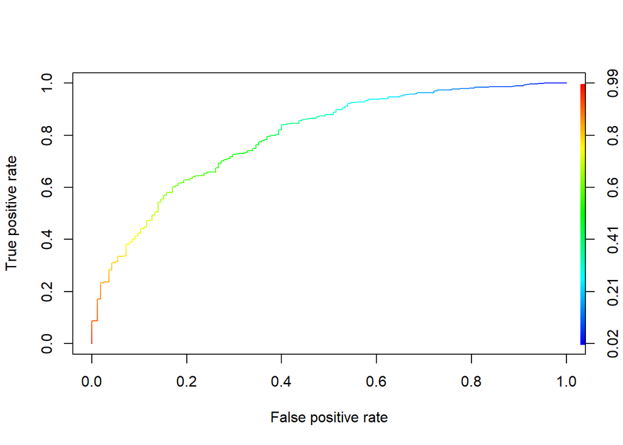

```r
modele<- lda(kredit ~ ., prior=c(0.5,0.5),data = data)
modele.posterior<-predict(modele, data)$posterior[,2]
modele.pred<-prediction(modele.posterior, data[,1])
modele.roc<-performance(modele.pred, "tpr","fpr")
plot(modele.roc,colorize=TRUE)
```

```r
modele.auc<-performance(modele.pred, "auc")
modele.auc@y.values[[1]]
```

```
## [1] 0.7950197
```

```r
modele<- qda(kredit ~ ., prior=c(0.5,0.5),data = data) #analyse discriminante quadratique
modele
```

```
## Call:
## qda(kredit ~ ., data = data, prior = c(0.5, 0.5))
##
## Prior probabilities of groups:
##   0   1
## 0.5 0.5
##
## Group means:
##   laufkont laufzeit    moral     verw    hoehe sparkont  beszeit     rate
## 0 2.642424 25.04848 2.248485 3.272727 4367.279 1.830303 3.072727 2.969697
## 1 3.327986 19.47059 2.723708 2.926916 2995.820 2.436720 3.508021 2.932264
##     famges   buerge wohnzeit     verm    alter weitkred     wohn bishkred
## 0 2.587879 1.121212 2.690909 2.593939 33.83030 2.509091 1.933333 1.406061
## 1 2.734403 1.124777 2.812834 2.278075 36.14439 2.736185 1.937611 1.420677
##      beruf     pers    telef  gastarb
## 0 3.000000 1.151515 1.412121 1.006061
## 1 2.889483 1.139037 1.427807 1.037433
```

```r
TC0<-table(predict(modele, data)$class,data[,1])
TC0
```

```
##
##       0   1
##   0 133 147
##   1  32 414
```

```r
prec0=(TC0[1,1]+TC0[2,2])/sum(TC0)
prec0
```

```
## [1] 0.7534435
```

```r
#Modèle avec validation croisée
modele<- qda(kredit ~ ., prior=c(0.5,0.5),CV=TRUE,data = data) #analyse discriminante quadratique
prevCV<-modele$class
TC0<-table(prevCV,data[,1])
TC0
```

```
##
## prevCV   0   1
##      0 109 172
##      1  56 389
```

```r
prec0=(TC0[1,1]+TC0[2,2])/sum(TC0)
prec0
```

```
## [1] 0.6859504
```

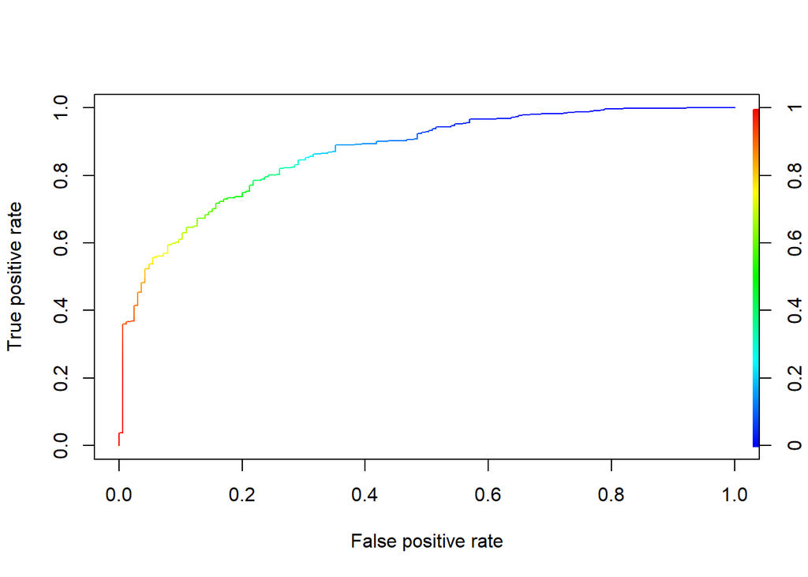

```r
library(ROCR)
modele<- qda(kredit ~ ., prior=c(0.5,0.5),data = data)
modele.posterior<-predict(modele, data)$posterior[,2]
modele.pred<-prediction(modele.posterior, data[,1])
modele.roc<-performance(modele.pred, "tpr","fpr")
plot(modele.roc,colorize=TRUE)
```

```r
modele.auc<-performance(modele.pred, "auc")
modele.auc@y.values[[1]]
```

```
## [1] 0.866591
```

Plusieurs façons de sélectionner:

**Backward:** On part de toutes les variables disponibles et on enlève au fur et à mesure les variables non significatives

**Forward:** Le contraire de Backward

**Both:** Dans les deux directions (équivalent de stepwise sous SAS). En général, on s’appuie sur le critère d’Akaïke (AIC) ou de Scharwz (BIC) que l’on souhaite minimiser : Ces critères à peu de choses près équivalents traduisent la complexité du modèle au fur et à mesure que l’on rajoute des variables (donc des paramètres à estimer). Dans notre exemple, mettons en oeuvre les différentes sélections.

```r
# modèle trivial réduit à la constante
str_constant <- "~ 1"
# modèle complet incluant toutes les explicatives potentielles
str_all <- "~laufkont+laufzeit+moral+verw+hoehe+sparkont+beszeit+rate+famges+
buerge+wohnzeit+verm+alter+weitkred+wohn+bishkred+beruf+pers+telef+gastarb"
```

**Forward:**

```r
modele<- glm(kredit ~ 1, data = data.factor, family = binomial)
modele.forward <- stepAIC(modele, scope = list(lower = str_constant, upper = str_all),
    trace = TRUE, data = data.factor, direction = "forward")
```

```
## Start:  AIC=780.21
## kredit ~ 1
##
##            Df Deviance    AIC
## + laufkont  2   710.61 716.61
## + hoehe     1   752.40 756.40
## + laufzeit  1   753.20 757.20
## + moral     4   747.61 757.61
## + verw      9   742.10 762.10
## + sparkont  4   755.05 765.05
## + beszeit   4   755.75 765.75
## + weitkred  2   764.10 770.10
## + verm      3   764.74 772.74
## + wohn      2   768.17 774.17
## + beruf     3   766.70 774.70
## + alter     1   772.37 776.37
## + gastarb   1   772.43 776.43
## + famges    3   770.41 778.41
## + buerge    2   772.75 778.75
## <none>          778.21 780.21
## + pers      1   778.05 782.05
## + telef     1   778.09 782.09
## + wohnzeit  3   775.14 783.14
## + bishkred  3   775.88 783.88
## + rate      3   777.28 785.28
##
## Step:  AIC=716.61
## kredit ~ laufkont
##
##            Df Deviance    AIC
## + hoehe     1   691.70 699.70
## + laufzeit  1   691.97 699.97
## + verw      9   682.07 706.07
## + moral     4   694.48 708.48
## + beszeit   4   695.63 709.63
## + weitkred  2   699.98 709.98
## + sparkont  4   696.11 710.11
## + buerge    2   700.59 710.59
## + verm      3   699.22 711.22
## + wohn      2   702.65 712.65
```

[output cut: 195 more lines]

```
## Step:  AIC=657.78
## kredit ~ laufkont + hoehe + verw + beszeit + sparkont + gastarb +
##     moral + rate + weitkred + buerge + alter
##
##            Df Deviance    AIC
## <none>          589.78 657.78
## + pers      1   587.80 657.80
## + telef     1   587.88 657.88
## + laufzeit  1   588.36 658.36
## + wohnzeit  3   584.45 658.45
## + wohn      2   586.74 658.74
## + famges    3   585.57 659.57
## + beruf     3   586.47 660.47
## + bishkred  3   587.56 661.56
## + verm      3   588.24 662.24
```

```r
# affichage du modèle final
summary(modele.forward)
```

```
##
## Call:
## glm(formula = kredit ~ laufkont + hoehe + verw + beszeit + sparkont +
##     gastarb + moral + rate + weitkred + buerge + alter, family = binomial,
##     data = data.factor)
##
## Deviance Residuals:
##      Min        1Q    Median        3Q       Max
## -2.81724   0.08521   0.40004   0.64550   2.50683
##
## Coefficients:
##               Estimate Std. Error z value Pr(>|z|)
## (Intercept) -1.217e+00  9.183e-01  -1.325 0.185062
## laufkont3    6.679e-01  3.740e-01   1.786 0.074117 .
## laufkont4    1.358e+00  2.331e-01   5.829 5.58e-09 ***
## hoehe       -1.942e-04  4.064e-05  -4.778 1.77e-06 ***
## verw1        1.819e+00  4.944e-01   3.679 0.000234 ***
## verw2        4.580e-01  3.353e-01   1.366 0.172020
## verw3        9.385e-01  2.991e-01   3.138 0.001700 **
## verw4        1.595e+01  7.939e+02   0.020 0.983972
## verw5        4.029e-01  6.309e-01   0.639 0.523056
## verw6       -2.079e-01  4.578e-01  -0.454 0.649717
## verw8        1.574e+01  7.875e+02   0.020 0.984051
## verw9        4.838e-01  3.618e-01   1.337 0.181165
## verw10       1.660e+00  9.360e-01   1.774 0.076105 .
## beszeit2    -1.701e-01  4.969e-01  -0.342 0.732203
## beszeit3     4.433e-02  4.671e-01   0.095 0.924383
## beszeit4     1.130e+00  5.278e-01   2.142 0.032210 *
## beszeit5     3.927e-01  4.819e-01   0.815 0.415119
## sparkont2    1.760e-01  3.093e-01   0.569 0.569283
## sparkont3    3.454e-02  4.252e-01   0.081 0.935259
## sparkont4    9.021e-01  5.435e-01   1.660 0.096984 .
## sparkont5    1.057e+00  3.281e-01   3.223 0.001270 **
## gastarb2     2.436e+00  1.255e+00   1.941 0.052276 .
## moral1       4.625e-02  6.966e-01   0.066 0.947058
## moral2       8.075e-01  5.117e-01   1.578 0.114544
## moral3       1.030e+00  5.574e-01   1.848 0.064647 .
## moral4       1.294e+00  5.399e-01   2.396 0.016561 *
## rate2       -4.880e-01  3.701e-01  -1.319 0.187280
## rate3       -7.686e-01  4.164e-01  -1.846 0.064929 .
## rate4       -9.726e-01  3.541e-01  -2.747 0.006013 **
## weitkred2    7.022e-02  5.072e-01   0.138 0.889900
## weitkred3    6.411e-01  2.900e-01   2.210 0.027093 *
## buerge2     -9.578e-01  5.406e-01  -1.772 0.076425 .
## buerge3      7.203e-01  5.553e-01   1.297 0.194546
## alter        1.854e-02  1.108e-02   1.674 0.094142 .
## ---
## Signif. codes:  0 '***' 0.001 '**' 0.01 '*' 0.05 '.' 0.1 ' ' 1
##
## (Dispersion parameter for binomial family taken to be 1)
##
##     Null deviance: 778.21  on 725  degrees of freedom
## Residual deviance: 589.78  on 692  degrees of freedom
## AIC: 657.78
##
## Number of Fisher Scoring iterations: 15
```

**Backward:**

```r
modele<- glm(kredit~., data = data.factor, family = binomial)
modele.backward <- stepAIC(modele, scope = list(lower = str_constant, upper = str_all),
trace = TRUE, data = data.factor, direction = "backward")
```

```
## Start:  AIC=668.53
## kredit ~ laufkont + laufzeit + moral + verw + hoehe + sparkont +
##     beszeit + rate + famges + buerge + wohnzeit + verm + alter +
##     weitkred + wohn + bishkred + beruf + pers + telef + gastarb
##
##            Df Deviance    AIC
## - verm      3   562.04 664.04
## - bishkred  3   563.50 665.50
## - beruf     3   564.99 666.99
## - wohn      2   563.36 667.36
## - laufzeit  1   562.19 668.19
## - famges    3   566.47 668.47
## <none>          560.53 668.53
## - weitkred  2   564.76 668.76
## - buerge    2   564.79 668.79
## - rate      3   566.91 668.91
## - telef     1   562.97 668.97
## - alter     1   563.21 669.21
## - wohnzeit  3   567.41 669.41
## - moral     4   570.56 670.56
## - pers      1   564.70 670.70
## - gastarb   1   566.35 672.35
## - sparkont  4   572.65 672.65
## - hoehe     1   567.24 673.24
## - beszeit   4   574.45 674.45
## - verw      9   588.94 678.94
## - laufkont  2   596.51 700.51
##
## Step:  AIC=664.04
## kredit ~ laufkont + laufzeit + moral + verw + hoehe + sparkont +
##     beszeit + rate + famges + buerge + wohnzeit + alter + weitkred +
##     wohn + bishkred + beruf + pers + telef + gastarb
##
##            Df Deviance    AIC
## - bishkred  3   564.84 660.84
## - beruf     3   566.86 662.86
## - famges    3   567.62 663.62
## - laufzeit  1   563.80 663.80
## <none>          562.04 664.04
## - wohn      2   566.13 664.13
```

[output cut: 139 more lines]

```
##            Df Deviance    AIC
## <none>          583.82 657.82
## - wohn      2   588.29 658.29
## - pers      1   586.37 658.37
## - moral     4   592.41 658.41
## - buerge    2   589.01 659.01
## - weitkred  2   589.02 659.02
## - hoehe     1   587.29 659.29
## - wohnzeit  3   591.88 659.88
## - laufzeit  1   588.83 660.83
## - gastarb   1   590.58 662.58
## - sparkont  4   598.67 664.67
## - beszeit   4   600.44 666.44
## - verw      9   613.34 669.34
## - laufkont  2   620.29 690.29
```

```r
# affichage du modèle final
summary(modele.backward)
```

```
##
## Call:
## glm(formula = kredit ~ laufkont + laufzeit + moral + verw + hoehe +
##     sparkont + beszeit + buerge + wohnzeit + weitkred + wohn +
##     pers + gastarb, family = binomial, data = data.factor)
##
## Deviance Residuals:
##      Min        1Q    Median        3Q       Max
## -2.74998   0.07511   0.36617   0.62923   2.13742
##
## Coefficients:
##               Estimate Std. Error z value Pr(>|z|)
## (Intercept) -9.765e-01  8.820e-01  -1.107 0.268247
## laufkont3    6.958e-01  3.692e-01   1.885 0.059473 .
## laufkont4    1.402e+00  2.386e-01   5.875 4.23e-09 ***
## laufzeit    -2.455e-02  1.099e-02  -2.233 0.025542 *
## moral1       2.195e-01  7.103e-01   0.309 0.757367
## moral2       8.173e-01  5.163e-01   1.583 0.113438
## moral3       1.166e+00  5.664e-01   2.060 0.039446 *
## moral4       1.239e+00  5.467e-01   2.266 0.023445 *
## verw1        1.862e+00  4.951e-01   3.761 0.000169 ***
## verw2        3.930e-01  3.374e-01   1.165 0.244159
## verw3        8.333e-01  3.026e-01   2.754 0.005891 **
## verw4        1.607e+01  7.750e+02   0.021 0.983459
## verw5        2.184e-01  6.367e-01   0.343 0.731602
## verw6       -6.373e-02  4.716e-01  -0.135 0.892491
## verw8        1.568e+01  7.776e+02   0.020 0.983908
## verw9        5.308e-01  3.701e-01   1.434 0.151478
## verw10       1.382e+00  9.190e-01   1.503 0.132761
## hoehe       -8.951e-05  4.824e-05  -1.855 0.063535 .
## sparkont2    2.252e-01  3.159e-01   0.713 0.475772
## sparkont3    2.189e-01  4.320e-01   0.507 0.612387
## sparkont4    9.541e-01  5.633e-01   1.694 0.090311 .
## sparkont5    1.107e+00  3.296e-01   3.359 0.000782 ***
## beszeit2    -3.640e-01  4.983e-01  -0.731 0.465028
## beszeit3     7.611e-02  4.615e-01   0.165 0.868997
## beszeit4     1.116e+00  5.326e-01   2.095 0.036169 *
## beszeit5     3.551e-01  4.831e-01   0.735 0.462262
## buerge2     -9.533e-01  5.369e-01  -1.775 0.075817 .
## buerge3      7.244e-01  5.513e-01   1.314 0.188841
## wohnzeit2   -8.670e-01  3.642e-01  -2.380 0.017289 *
## wohnzeit3   -5.681e-01  4.253e-01  -1.336 0.181595
## wohnzeit4   -2.962e-01  3.810e-01  -0.778 0.436855
## weitkred2   -5.446e-02  5.105e-01  -0.107 0.915037
## weitkred3    5.970e-01  2.948e-01   2.025 0.042881 *
## wohn2        6.332e-01  2.987e-01   2.120 0.034014 *
## wohn3        3.931e-01  4.361e-01   0.901 0.367403
## pers2       -4.982e-01  3.075e-01  -1.620 0.105176
## gastarb2     2.469e+00  1.262e+00   1.957 0.050344 .
## ---
## Signif. codes:  0 '***' 0.001 '**' 0.01 '*' 0.05 '.' 0.1 ' ' 1
##
## (Dispersion parameter for binomial family taken to be 1)
##
##     Null deviance: 778.21  on 725  degrees of freedom
## Residual deviance: 583.82  on 689  degrees of freedom
## AIC: 657.82
##
## Number of Fisher Scoring iterations: 15
```

Nous regardons la sélection au final faite par l’algoritme: *glm(formula = kredit ~ laufkont + laufzeit + moral + verw + hoehe + sparkont + beszeit + buerge + wohnzeit + weitkred + wohn + pers + gastarb, family = binomial, data = data)*. Il ne retient pas les variables **rate** (pas de mensualités dans le revenu disponible en %), **famges** (statut marital/sexe), **verm** (actif en dur), **alter** (âge), **bishkred** (nombre de précédents crédits à la banque), **beruf** (profession) et **telef** (profession d’une ligne téléphonique).

**BOTH: Stepwise:**

```r
modele<- glm(kredit ~ 1, data = data.factor, family = binomial)
modele.stepwise <- stepAIC(modele, scope = list(lower = str_constant, upper = str_all),
    trace = TRUE, data = data.factor, direction = "both")
```

```
## Start:  AIC=780.21
## kredit ~ 1
##
##            Df Deviance    AIC
## + laufkont  2   710.61 716.61
## + hoehe     1   752.40 756.40
## + laufzeit  1   753.20 757.20
## + moral     4   747.61 757.61
## + verw      9   742.10 762.10
## + sparkont  4   755.05 765.05
## + beszeit   4   755.75 765.75
## + weitkred  2   764.10 770.10
## + verm      3   764.74 772.74
## + wohn      2   768.17 774.17
## + beruf     3   766.70 774.70
## + alter     1   772.37 776.37
## + gastarb   1   772.43 776.43
## + famges    3   770.41 778.41
## + buerge    2   772.75 778.75
## <none>          778.21 780.21
## + pers      1   778.05 782.05
## + telef     1   778.09 782.09
## + wohnzeit  3   775.14 783.14
## + bishkred  3   775.88 783.88
## + rate      3   777.28 785.28
##
## Step:  AIC=716.61
## kredit ~ laufkont
##
##            Df Deviance    AIC
## + hoehe     1   691.70 699.70
## + laufzeit  1   691.97 699.97
## + verw      9   682.07 706.07
## + moral     4   694.48 708.48
## + beszeit   4   695.63 709.63
## + weitkred  2   699.98 709.98
## + sparkont  4   696.11 710.11
## + buerge    2   700.59 710.59
## + verm      3   699.22 711.22
## + wohn      2   702.65 712.65
```

[output cut: 261 more lines]

```
## + wohn      2   586.74 658.74
## - buerge    2   594.90 658.90
## - weitkred  2   595.36 659.36
## + famges    3   585.57 659.57
## - moral     4   599.94 659.94
## + beruf     3   586.47 660.47
## - rate      3   598.82 660.82
## + bishkred  3   587.56 661.56
## + verm      3   588.24 662.24
## - gastarb   1   596.26 662.26
## - sparkont  4   603.71 663.71
## - beszeit   4   604.61 664.61
## - verw      9   621.36 671.36
## - hoehe     1   614.05 680.05
## - laufkont  2   625.53 689.53
```

```r
# affichage du modèle final
summary(modele.stepwise)
```

```
##
## Call:
## glm(formula = kredit ~ laufkont + hoehe + verw + beszeit + sparkont +
##     gastarb + moral + rate + weitkred + buerge + alter, family = binomial,
##     data = data.factor)
##
## Deviance Residuals:
##      Min        1Q    Median        3Q       Max
## -2.81724   0.08521   0.40004   0.64550   2.50683
##
## Coefficients:
##               Estimate Std. Error z value Pr(>|z|)
## (Intercept) -1.217e+00  9.183e-01  -1.325 0.185062
## laufkont3    6.679e-01  3.740e-01   1.786 0.074117 .
## laufkont4    1.358e+00  2.331e-01   5.829 5.58e-09 ***
## hoehe       -1.942e-04  4.064e-05  -4.778 1.77e-06 ***
## verw1        1.819e+00  4.944e-01   3.679 0.000234 ***
## verw2        4.580e-01  3.353e-01   1.366 0.172020
## verw3        9.385e-01  2.991e-01   3.138 0.001700 **
## verw4        1.595e+01  7.939e+02   0.020 0.983972
## verw5        4.029e-01  6.309e-01   0.639 0.523056
## verw6       -2.079e-01  4.578e-01  -0.454 0.649717
## verw8        1.574e+01  7.875e+02   0.020 0.984051
## verw9        4.838e-01  3.618e-01   1.337 0.181165
## verw10       1.660e+00  9.360e-01   1.774 0.076105 .
## beszeit2    -1.701e-01  4.969e-01  -0.342 0.732203
## beszeit3     4.433e-02  4.671e-01   0.095 0.924383
## beszeit4     1.130e+00  5.278e-01   2.142 0.032210 *
## beszeit5     3.927e-01  4.819e-01   0.815 0.415119
## sparkont2    1.760e-01  3.093e-01   0.569 0.569283
## sparkont3    3.454e-02  4.252e-01   0.081 0.935259
## sparkont4    9.021e-01  5.435e-01   1.660 0.096984 .
## sparkont5    1.057e+00  3.281e-01   3.223 0.001270 **
## gastarb2     2.436e+00  1.255e+00   1.941 0.052276 .
## moral1       4.625e-02  6.966e-01   0.066 0.947058
## moral2       8.075e-01  5.117e-01   1.578 0.114544
## moral3       1.030e+00  5.574e-01   1.848 0.064647 .
## moral4       1.294e+00  5.399e-01   2.396 0.016561 *
## rate2       -4.880e-01  3.701e-01  -1.319 0.187280
## rate3       -7.686e-01  4.164e-01  -1.846 0.064929 .
## rate4       -9.726e-01  3.541e-01  -2.747 0.006013 **
## weitkred2    7.022e-02  5.072e-01   0.138 0.889900
## weitkred3    6.411e-01  2.900e-01   2.210 0.027093 *
## buerge2     -9.578e-01  5.406e-01  -1.772 0.076425 .
## buerge3      7.203e-01  5.553e-01   1.297 0.194546
## alter        1.854e-02  1.108e-02   1.674 0.094142 .
## ---
## Signif. codes:  0 '***' 0.001 '**' 0.01 '*' 0.05 '.' 0.1 ' ' 1
##
## (Dispersion parameter for binomial family taken to be 1)
##
##     Null deviance: 778.21  on 725  degrees of freedom
## Residual deviance: 589.78  on 692  degrees of freedom
## AIC: 657.78
##
## Number of Fisher Scoring iterations: 15
```

Nous regardons la sélection au final faite par l’algoritme: *glm(formula = kredit ~ aufkont + hoehe + verw + beszeit+ sparkont + gastarb + moral + rate + weitkred + buerge + alter, family = binomial, data = data)* Soient, les mêmes variables que dans la sélection forward.

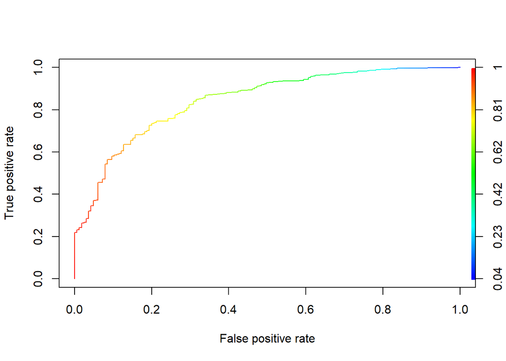

```r
modele<- glm(kredit ~ ., data = data.factor, family = binomial)
modele.posterior<-predict(modele, data.factor,type="response")
modele.pred<-prediction(modele.posterior, data.factor[,1])
modele.roc<-performance(modele.pred, "tpr","fpr")
plot(modele.roc,colorize=TRUE)
```

```r
modele.auc<-performance(modele.pred, "auc")
modele.auc@y.values[[1]]
```

```
## [1] 0.8432777
```

Passons maintenant à la méthode **des arbres de décision**.

Les arbres de décision sont couramment utilisés pour expliquer et/ou prédire les valeurs d’une variable à l’aide de variables explicatives qui peuvent être quantitatives ou qualitatives. Cette technique est l’une des plus intuitives et des plus populaires du data mining car elle fournit des règles explicites de classement.

Un arbre de décision est appelé **arbre de régression** (resp. **arbre de classification**) si la variable à expliquer est quantitative (resp. qualitative).

```r
library(rpart)
set.seed(101)
##échantillon aléatoire de 363 observations
row.app<-sample(1:nrow(data.factor), 0.75 * nrow(data.factor))
#construire et imprimer l'arbre calculé sur un échantillon
arbre.full <- rpart(kredit ~ ., data = data.factor[row.app,], method = "class")
print(arbre.full)
```

```
## n= 544
##
## node), split, n, loss, yval, (yprob)
##       * denotes terminal node
##
##    1) root 544 121 1 (0.22242647 0.77757353)
##      2) laufkont=2,3 250  87 1 (0.34800000 0.65200000)
##        4) hoehe>=9340.5 14   2 0 (0.85714286 0.14285714) *
##        5) hoehe< 9340.5 236  75 1 (0.31779661 0.68220339)
##         10) laufzeit>=26.5 57  28 1 (0.49122807 0.50877193)
##           20) verw=0,2,3,5,6,9 49  21 0 (0.57142857 0.42857143)
##             40) wohnzeit=2,3,4 37  11 0 (0.70270270 0.29729730) *
##             41) wohnzeit=1 12   2 1 (0.16666667 0.83333333) *
##           21) verw=1,4,10 8   0 1 (0.00000000 1.00000000) *
##         11) laufzeit< 26.5 179  47 1 (0.26256983 0.73743017)
##           22) moral=0,1 16   6 0 (0.62500000 0.37500000) *
##           23) moral=2,3,4 163  37 1 (0.22699387 0.77300613)
##             46) hoehe< 2878 117  33 1 (0.28205128 0.71794872)
##               92) laufzeit>=8.5 102  33 1 (0.32352941 0.67647059)
##                184) buerge=1,2 92  33 1 (0.35869565 0.64130435)
##                  368) verw=0,2,3,5 69  30 1 (0.43478261 0.56521739)
##                    736) weitkred=1 9   1 0 (0.88888889 0.11111111) *
##                    737) weitkred=2,3 60  22 1 (0.36666667 0.63333333)
##                     1474) alter< 39.5 45  20 1 (0.44444444 0.55555556)
##                       2948) laufzeit>=11 31  14 0 (0.54838710 0.45161290)
##                         5896) verw=2,3,5 21   7 0 (0.66666667 0.33333333) *
##                         5897) verw=0 10   3 1 (0.30000000 0.70000000) *
##                       2949) laufzeit< 11 14   3 1 (0.21428571 0.78571429) *
##                     1475) alter>=39.5 15   2 1 (0.13333333 0.86666667) *
##                  369) verw=1,4,6,8,9,10 23   3 1 (0.13043478 0.86956522) *
##                185) buerge=3 10   0 1 (0.00000000 1.00000000) *
##               93) laufzeit< 8.5 15   0 1 (0.00000000 1.00000000) *
##             47) hoehe>=2878 46   4 1 (0.08695652 0.91304348) *
##      3) laufkont=4 294  34 1 (0.11564626 0.88435374)
##        6) verw=5,6,9 54  14 1 (0.25925926 0.74074074)
##         12) beszeit=1,2 7   1 0 (0.85714286 0.14285714) *
##         13) beszeit=3,4,5 47   8 1 (0.17021277 0.82978723) *
##        7) verw=0,1,2,3,4,8,10 240  20 1 (0.08333333 0.91666667) *
```

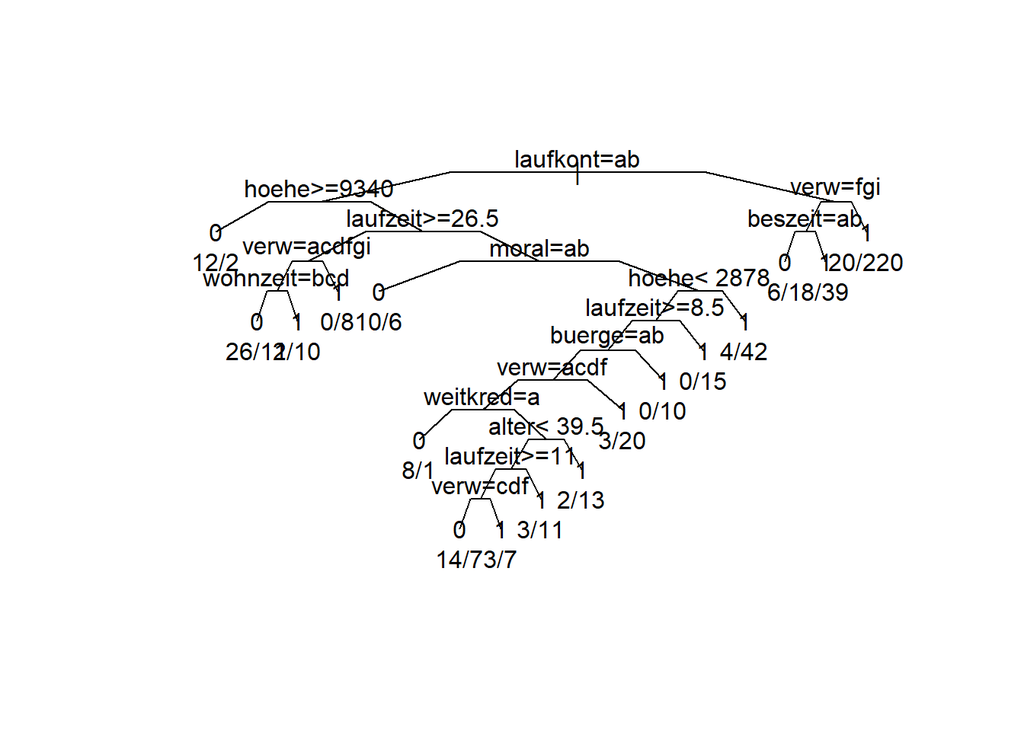

```r
#Impression d'un arbre sous forme graphique :
plot(arbre.full, uniform = TRUE, branch = 0.5, margin = 0.1)
text(arbre.full, all = FALSE, use.n = TRUE)
```

La sélection faite par l’algorithme qui semble l meilleure est la suivante: **laufkont=ab, verw=fgi** (càd les clients qui ne possèdent pas de compte ou avec absence de débit ayant pour objectifs de crédit soit la réparation soit l’éducation ou le recyclage).

Il est possible d’élaguer automatiquement un arbre de décision et de déterminer l’arbre optimal. La commande *printcp(arbre.full)* affiche une table qui va nous permettre de répondre à la question suivante (quel est l’arbre optimal?)

```r
##Elagage et paramètre de complexité
printcp(arbre.full)
```

```
##
## Classification tree:
## rpart(formula = kredit ~ ., data = data.factor[row.app, ], method = "class")
##
## Variables actually used in tree construction:
##  [1] alter    beszeit  buerge   hoehe    laufkont laufzeit moral
##  [8] verw     weitkred wohnzeit
##
## Root node error: 121/544 = 0.22243
##
## n= 544
##
##         CP nsplit rel error xerror     xstd
## 1 0.041322      0   1.00000 1.0000 0.080164
## 2 0.033058      5   0.79339 1.0496 0.081543
## 3 0.020661      6   0.76033 1.0000 0.080164
## 4 0.011570      8   0.71901 1.0331 0.081092
## 5 0.010000     16   0.60331 1.1240 0.083467
```

L’arbre le plus élagué (ligne 1 de la cptable) s’obtient pour cp dans l’intervalle ]cp1; 1], le deuxième (un peu moins élagué) (ligne 2 de la cptable) s’obtient pour cp dans l’intervalle ]cp2; cp1], le troisième (encore un peu moins élagué) (ligne 3 de la cptable) s’obtient pour cp dans l’intervalle ]cp3; cp2], etc.

Notez bien que la borne inférieure de l’intervalle est exclus : la valeur de cp = cp2 correspond à l’arbre 3, pas au 2.

```r
#deux manière d'élager l'arbre, soit simplement en faisant
arbre.full.prune<-prune(arbre.full,cp=0.02)

#ou bien en utilisant le paramètre de control :
donnees.factor.cnt <- rpart.control (minsplit = 1,cp=0.02)
arbre.full.prune<-rpart(kredit ~ ., data = data.factor, method = "class",control=donnees.factor.cnt)

#matrice de confusion et erreur en resubstitution
pred <- predict(arbre.full.prune, newdata = data.factor, type = "class")
mc <- table(kredit,pred) #matrice de confusion
print(mc)
```

```
##       pred
## kredit   0   1
##      0  79  86
##      1  27 534
```

```r
err.resub <- 1.0 - (mc[1,1]+mc[2,2])/sum(mc)
print(err.resub)
```

```
## [1] 0.1556474
```

Passons maintenant à la méthode **des forêts aléatoires**.

```r
library(randomForest)
set.seed(101)
##échantillon aléatoire de 363 observations
row.app<-sample(1:nrow(data.factor),363)
row.test<-sample(1:nrow(data.factor),363)
modele.RF<-randomForest(kredit~.,data=data.factor,subset=row.app)
```

On ordonne les variables selon leur mesure d’importance:

```r
imp<-importance(modele.RF)
order(imp,decreasing=TRUE)
```

```
##  [1]  5 13  2  4  7  3  1  6 11  8  9 12 17 14 15 16 19 18 10 20
```

On obtient l’erreur OOB de la forêt via

```r
modele.RF$err.rate[500,1]
```

```
##       OOB
## 0.2286501
```

On compare cette erreur avec l’erreur estimée sur l’échantillon de validation:

```r
data.test<-data.factor[row.test,]
 prev <- predict(modele.RF,newdata=data.test)
 sum(prev!=data.test$kredit)/nrow(data.test)
```

```
## [1] 0.09366391
```

Nous allons maintenant comparer les performances des forêts aléatoires avec la règle des k plus proches voisins et les arbres de classification (construits avec rpart). Pour **la règle des k plus proches voisins**, on choisit le nombre de voisins qui minimise le taux de mal classés sur l’échantillon d’apprentissage:

```r
library(class)
data.app<-data.factor[row.app,]
K <- seq(1,50,by=1)
err <- K
ind <- 0
 for (i in K){
ind <- ind+1
mod_ppv <- knn(train=data.app[,-1],test=data.test[,-1],cl=data.app$kredit,k=K[ind])
 err[ind] <- sum(mod_ppv!=data.test[,1])/nrow(data.test)
}
min(err)
```

```
## [1] 0.1735537
```

On obtient près de 17% d’erreur: on retrouve bien que les performances de la règle des plus proches voisins sont faibles en grande dimension.

Construisons maintenant **un arbre de classification** avec la fonction *rpart* du package *rpart*:

```r
library(rpart)
arbre <- rpart(kredit~.,data=data.app,cp=0.002)
```

L’arbre est sélectionné en minimisant un critère d’erreur (estimé par validation croisée) en fonction d’un paramètre appelé cp. Nous représentons l’arbre construit ainsi que le critère estimé en fonction de cp.

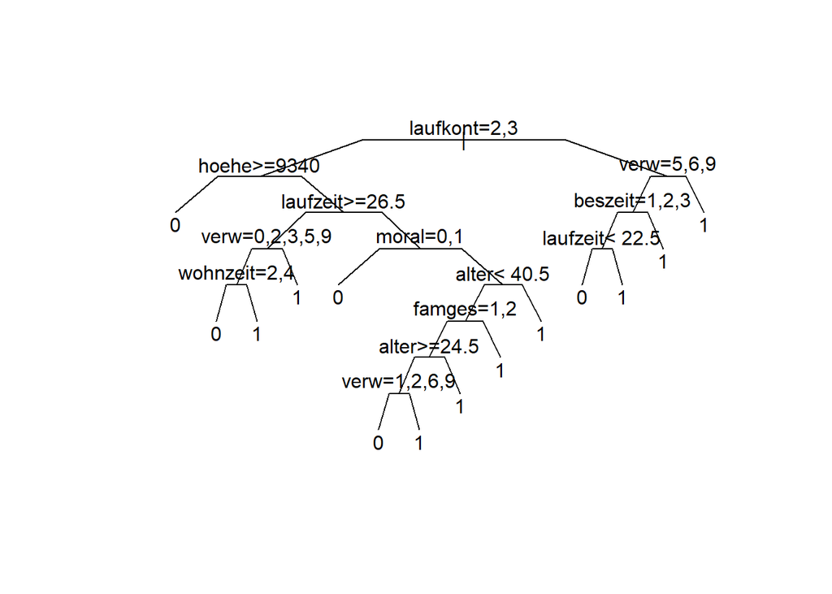

```r
plot(arbre,uniform = TRUE, branch = 0.5, margin = 0.1)
text(arbre,pretty=0)
```

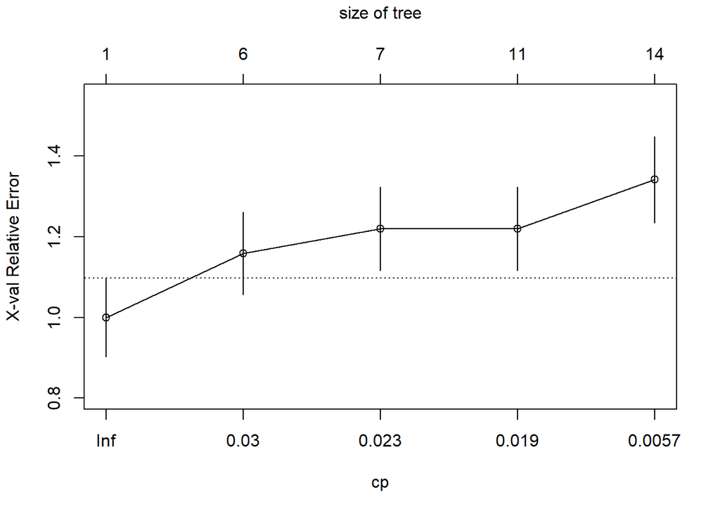

```r
plotcp(arbre)
```

```r
prev_arbre <- predict(arbre,newdata=data.test,type="class")
err_arbre <- sum(prev_arbre!=data.test$kredit)/nrow(data.test)
err_arbre
```

```
## [1] 0.1955923
```

On obtient pour cet arbre un taux d’erreur estimé de 0.196.